# Workshop 1/2: Introduction to transcriptomics

Functional analyses in transcriptomics

January Weiner

2021-06-19

# Preparation

Download the files `counts45.txt`, `covar45.txt` and `annot45.txt` from the github repository. These RDS files are contain, respectively, the counts, the covariates and gene annotation for 45 samples from the data set GSE156063. These RDS files contain R objects saved with the `saveRDS` function.

The only reason we use the RDS files is that they are smaller than the corresponding TSV/CSV text files. You can load them as follows:

```r
counts <- read.table("counts45.txt")
covar  <- read.table("covar45.txt")
annot  <- read.table("annot45.txt")
```

There are three groups of data in the covariate file.

```r
library(colorDF)
summary_colorDF(covar)
```

```
## # Color data frame (class colorDF) 5 x 12:
##   │Col          │Class│NAs  │unique│Summary
##  1│label        │<chr>│    0│    45│All values unique
##  2│filename     │<chr>│    0│    45│All values unique
##  3│md5          │<chr>│    0│    45│All values unique
##  4│replicate    │<int>│    0│     1│1
##  5│title        │<chr>│    0│    45│All values unique
##  6│geo_accession│<chr>│    0│    45│All values unique
##  7│age          │<dbl>│    0│    35│22 [36 <55> 68] 89
##  8│disease_state│<chr>│    0│     3│no virus: 15, other virus: 15, SC2: 15
##  9│gender       │<chr>│    0│     2│M: 29, F: 16
## 10│group        │<chr>│    0│     3│no: 15, other: 15, SC2: 15
## 11│sizeFactor   │<dbl>│    0│    45│0.133 [0.456 <0.978> 1.931] 7.484
## 12│replaceable  │<lgl>│    0│     1│TRUE: 45 FALSE: 0
```

**Exercise. (10 minutes)** Take a look at the `covar` object. How many females and how many males are there? How many females have COVID-19, and how many males are healthy? What is the average age in the male and female groups? Hint: use the `table` function.

## Differential gene expression analysis

To run a basic gene expression analysis, we need to use the DESeq2 package. The steps are as follows:

- Create the DESeq2 object with counts and covariates
- Run the calculations – fit the model
- Extract the results

First two steps are below:

```r
library(DESeq2)
ds2 <- DESeqDataSetFromMatrix(countData=counts,
                              colData=covar,
                              design= ~ group)
ds2 <- DESeq(ds2)
```

The ds2 contains now the fitted model. We now have to get the results, but for that, we need to know the names of the results:

```r
resultsNames(ds2)
```

```
## [1] "Intercept"         "group_other_vs_no" "group_SC2_vs_no"
```

```r
res_sc2 <- results(ds2, name="group_SC2_vs_no")
res_sc2 <- as.data.frame(res_sc2)
print_colorDF(head(res_sc2))
```

```
## # Data frame like object (class data.frame) 6 x 6:
##                │baseMean│log2FoldChange│lfcSE│stat  │pvalue │padj
## ENSG00000000003│     370│         0.509│ 0.41│ 1.255│0.209  │0.8098
## ENSG00000000419│      60│         0.180│ 0.32│ 0.554│0.579  │0.9538
## ENSG00000000460│      56│         0.278│ 0.34│ 0.823│0.410  │0.9234
## ENSG00000000938│     452│        -1.630│ 0.84│-1.932│0.053  │0.5548
## ENSG00000000971│     277│         1.581│ 0.35│ 4.552│5.3e-06│0.0023
## ENSG00000001036│     116│        -0.018│ 0.28│-0.062│0.950  │0.9920
```

This is not very interesting, unless we merge it with the annotation table and order by p-values. The row names of `res_sc2` correspond to the column “ENSEMBL” of `annot`:

```r
## merge by ENSEMBL column from annot and rownames ("0")
## from res
res_sc2 <- merge(annot, res_sc2, by.x="ENSEMBL", by.y=0) %>%
  arrange(pvalue)
knitr::kable(head(res_sc2))
```

| ENSEMBL | SYMBOL | GENENAME | baseMean | log2FoldChange | lfcSE | stat | pvalue | padj |
| --- | --- | --- | --- | --- | --- | --- | --- | --- |
| ENSG00000126709 | IFI6 | interferon alpha inducible protein 6 | 676.6069 | 3.019484 | 0.4997842 | 6.041576 | 0 | 1.22e-05 |
| ENSG00000138642 | HERC6 | HECT and RLD domain containing E3 ubiquitin protein ligase family member 6 | 385.4486 | 2.539668 | 0.4306000 | 5.897974 | 0 | 1.22e-05 |
| ENSG00000169245 | CXCL10 | C-X-C motif chemokine ligand 10 | 460.9647 | 5.207046 | 0.8831769 | 5.895813 | 0 | 1.22e-05 |
| ENSG00000137628 | DDX60 | DExD/H-box helicase 60 | 635.5409 | 2.361766 | 0.4050831 | 5.830325 | 0 | 1.22e-05 |
| ENSG00000130032 | PRRG3 | proline rich and Gla domain 3 | 682.5724 | -3.948837 | 0.6778485 | -5.825545 | 0 | 1.22e-05 |
| ENSG00000137959 | IFI44L | interferon induced protein 44 like | 1517.2810 | 2.720096 | 0.4678168 | 5.814449 | 0 | 1.22e-05 |

**Exercise. (10 minutes)**. How many genes are significant at padj < 0.05? How many at padj < 0.01? (padj is the false discovery rate from the Benjamini-Hochberg procedure). How many are significant at padj < 0.05 and abs(log2FoldChange) > 1?

**Exercise. (15 minutes)**. Repeat the above steps for the other comparison (other virus vs. no virus) generating a suitable data frame. Merge the two result tables and plot the log2 fold changes from one comparison vs the log2 fold changes from the other comparison. What do you notice?

**Exercise. (extra)** The model `~ group` fits the data using `group` as predictor. To find genes that are related to age, you would use a model like `~ age`. Using DESeq2, find genes that show a significant association with age (repeat the steps above with a new model).

## Visualizing the results

To visualize the results, we need to first calculate the log-counts per million. One could use here the `cpm` function from the package `edgeR`, but we will do it manually. We need, however, to add a small value to all results to avoid log2(0).

```r
counts <- as.matrix(counts)
cpm <- counts + 2
lib_sizes <- colSums(cpm) / 1e6 # library sizes in millions
## a neat trick to divide a matrix by a row
cpm <- t(t(cpm) / lib_sizes)
cpm <- log2(cpm)
```

Now we can plot the top results.

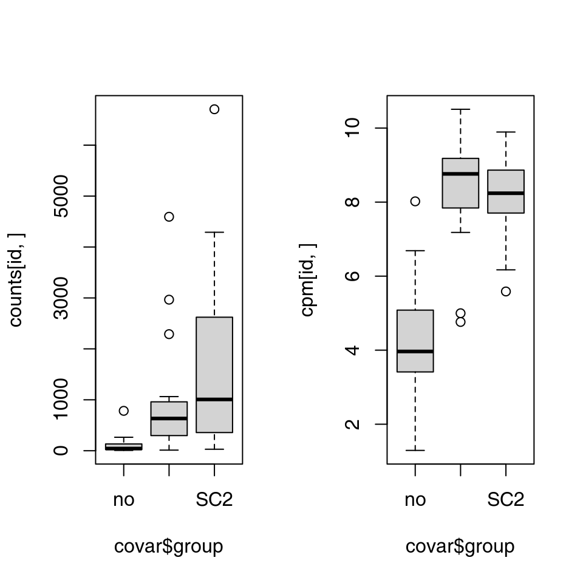

```r
par(mfrow=c(1,2))
id <- "ENSG00000126709" # IFI6
boxplot(counts[id, ] ~ covar$group)
boxplot(cpm[id, ] ~ covar$group)
```

**Exercise. (5min)** Choose another gene and plot it.

To create a heatmap, we can use the very simple `heatmap` function. We will select the top 25 genes for that:

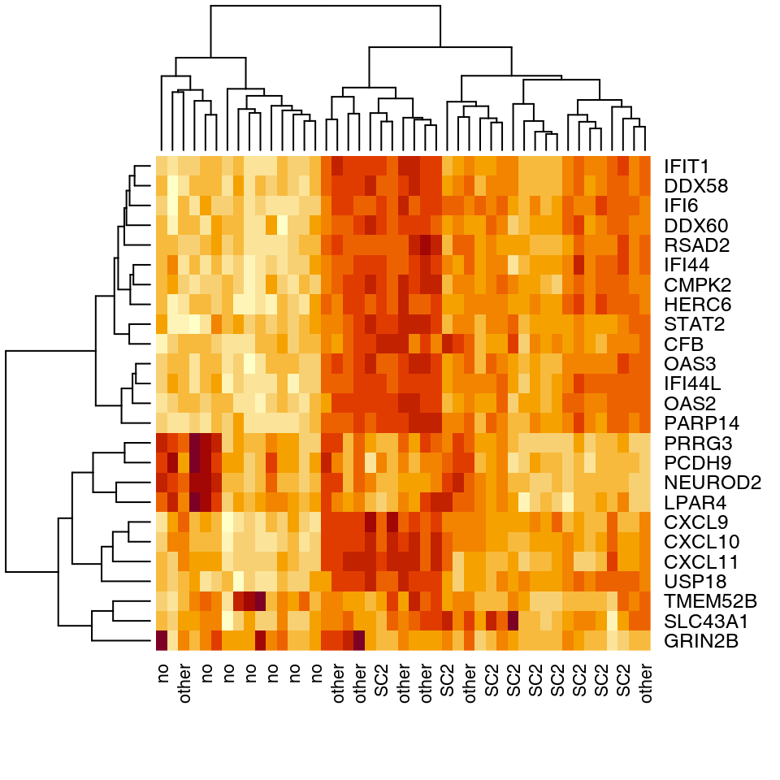

```r
sel <- res_sc2$ENSEMBL[1:25]
x <- cpm[sel, ]
colnames(x) <- covar$group
rownames(x) <- annot$SYMBOL[ match(sel, annot$ENSEMBL) ]
heatmap(x)
```

**Exercise. (15min)** Create PCA based on the CPM of the top 500 genes (see practicals 5 and 7).

## Gene set enrichment analysis

### Gene set enrichment

Gene set enrichment analysis with tmod is as simple as this:

```r
library(tmod)
res_tmod <- tmodCERNOtest(res_sc2$SYMBOL)
res_tmod
```

```
## # tmod report (class tmodReport) 8 x 53:
## # (Showing rows 1 - 30 out of 53)
##          │ID       │Title                                                          │cerno│N1
##    LI.M75│   LI.M75│antiviral IFN signature                                        │  176│   20
##   LI.M127│  LI.M127│type I interferon response                                     │  118│   12
##   LI.M165│  LI.M165│enriched in activated dendritic cells (II)                     │  187│   32
##  LI.M11.0│ LI.M11.0│enriched in monocytes (II)                                     │  513│  157
##    LI.M67│   LI.M67│activated dendritic cells                                      │   89│   11
##   LI.M150│  LI.M150│innate antiviral response                                      │   78│    9
##    LI.M68│   LI.M68│RIG-1 like receptor signaling                                  │   74│    9
##   LI.M4.0│  LI.M4.0│cell cycle and transcription                                   │  781│  286
##     LI.S4│    LI.S4│Monocyte surface signature                                     │  252│   70
## LI.M111.1│LI.M111.1│viral sensing & immunity; IRF2 targets network (II)            │   72│    9
##  LI.M37.0│ LI.M37.0│immune activation - generic cluster                            │  682│  246
##  LI.M27.0│ LI.M27.0│chemokine cluster (I)                                          │   94│   17
##    LI.S11│   LI.S11│Activated (LPS) dendritic cell surface signature               │  129│   29
##    LI.M13│   LI.M13│innate activation by cytosolic DNA sensing                     │   63│   10
##  LI.M27.1│ LI.M27.1│chemokine cluster (II)                                         │   68│   12
##    LI.M20│   LI.M20│AP-1 transcription factor network                              │   72│   14
## LI.M118.0│LI.M118.0│enriched in monocytes (IV)                                     │  157│   44
##    LI.M16│   LI.M16│TLR and inflammatory signaling                                 │  153│   43
##  LI.M37.1│ LI.M37.1│enriched in neutrophils (I)                                    │  156│   44
## LI.M112.0│LI.M112.0│complement activation (I)                                      │   75│   16
## LI.M112.1│LI.M112.1│complement activation (II)                                     │   47│    8
## LI.M111.0│LI.M111.0│viral sensing & immunity; IRF2 targets network (I)             │   68│   15
##  LI.M35.0│ LI.M35.0│signaling in T cells (I)                                       │   63│   14
##  LI.M11.1│ LI.M11.1│blood coagulation                                              │   75│   18
##   LI.M7.0│  LI.M7.0│enriched in T cells (I)                                        │  153│   48
##     LI.M0│    LI.M0│targets of FOSL1/2                                             │   50│   10
##   LI.M163│  LI.M163│enriched in neutrophils (II)                                   │   56│   12
## LI.M118.1│LI.M118.1│enriched in monocytes (surface)                                │   54│   12
##    LI.M94│   LI.M94│growth factor induced, enriched in nuclear receptor subfamily 4│   43│    9
##  LI.M95.1│ LI.M95.1│enriched in antigen presentation (III)                         │   51│   12
##          │AUC  │cES  │P.Value│adj.P.Val
##    LI.M75│ 0.89│  4.4│< 2e-16│2.2e-16
##   LI.M127│ 0.93│  4.9│2.5e-14│4.4e-12
##   LI.M165│ 0.77│  2.9│5.5e-14│6.3e-12
##  LI.M11.0│ 0.68│  1.6│9.8e-12│8.5e-10
##    LI.M67│ 0.85│  4.0│5.5e-10│3.8e-08
##   LI.M150│ 0.90│  4.3│2.0e-09│1.2e-07
```

[output cut: 9 more lines]

```
##    LI.M20│ 0.87│  2.6│9.1e-06│0.00019
## LI.M118.0│ 0.68│  1.8│9.4e-06│0.00019
##    LI.M16│ 0.72│  1.8│1.2e-05│0.00022
##  LI.M37.1│ 0.74│  1.8│1.2e-05│0.00022
## LI.M112.0│ 0.68│  2.3│2.7e-05│0.00046
## LI.M112.1│ 0.74│  2.9│7.2e-05│0.00118
## LI.M111.0│ 0.73│  2.3│0.00010│0.00162
##  LI.M35.0│ 0.78│  2.3│0.00015│0.00231
##  LI.M11.1│ 0.81│  2.1│0.00016│0.00235
##   LI.M7.0│ 0.68│  1.6│0.00018│0.00245
##     LI.M0│ 0.78│  2.5│0.00022│0.00291
##   LI.M163│ 0.87│  2.3│0.00025│0.00322
## LI.M118.1│ 0.82│  2.2│0.00045│0.00561
##    LI.M94│ 0.79│  2.4│0.00073│0.00867
##  LI.M95.1│ 0.85│  2.1│0.00094│0.01080
```

**Exercise. (20min)** Run the enrichment analysis for the other comparison. Compare the results of the enrichment (AUC, p-values) on a plot.

### ORA (Overrepresentation Analysis)

We will select genes from a single gene set and test them using a $\chi^2$ test.

```r
degs <- abs(res_sc2$log2FoldChange) > 1 & res_sc2$padj < 0.05
degs <- ifelse(degs, "DEG", "NS")
data(tmod)
ifn <- tmod$MODULES2GENES[["LI.M75"]]
ings <- res_sc2$SYMBOL %in% ifn
ings <- ifelse(ings, "IFN", "Other")
table(ings, degs)
```

```
##        degs
## ings      DEG    NS
##   IFN      10    10
##   Other   104 11860
```

```r
chisq.test(table(ings, degs))
```

```
##
##  Pearson's Chi-squared test with Yates' continuity correction
##
## data:  table(ings, degs)
## X-squared = 460.7, df = 1, p-value < 2.2e-16
```